# Physical and Reproductive Allocation in *Cylindropuntia acanthocarpa*

Malory Owen & Christopher Lortie

2019

# Introduction

Plants make trade offs, just like any organism. We know that many plants make allocational trade offs between the growth of physical, defensive, and reproductive structures, putting more energy or nutrients towards one or two of these groups of structures. For pollinators and seed dispersers, size and showiness influence visitation; that is, larger plants or plants with more flowers/fruits are more likely to attract flying pollinators. To this end, we are interested in investigating what trade offs are made in a apidae-pollinated cactus, *Cylindropuntia acanthocarpa*. We hypothesize that physical and reproductive structures will have a negative relationship at median levels of structural output, but will plateau as cacti reach their maximum size.

Metrics of physical output (predictor variables) are:

1. Volume
2. Total branches
3. New growth branches

Metrics of reproductive output (response variables) are:

1. Flower buds per cactus
2. Fruits per cactus
3. Blooming flowers on June 8th, 2019
4. Fruit weight
5. Fruit volume
6. Seed weight (being collected now)
7. Seeds per fruit/cactus (being collected now)

# Dataset

```
##   cactus.id tag  X      lat       lon   x   y  z  volume newgrowth health
## 1         1 400 NA 34.78159 -115.6625  53  49 52  135044        15      5
## 2         2 399 NA 34.78162 -115.6625  71  60 55  234300        20      3
## 3         3 398 NA 34.78164 -115.6624  20  13 23    5980        18      5
## 4         4 397 NA 34.78157 -115.6624 120 103 85 1050600       100      4
## 5         5 396 NA 34.78162 -115.6623   9   5 26    1170         3      5
## 6         6 395 NA 34.78164 -115.6622  82  63  4   20664        75      4
##   branches transect meter distance blooms buds fruits nest notes
## 1      210        1     5        1      1  100     32    1
## 2      500        1    10        0      1   90     21    0
## 3       50        1    15        2      0    0      0    0
## 4     1000        1    20        4      1  390    156    1
## 5       10        1    25        0      0    0      0    0
## 6      600        1    30        0      1  600     42    0
```

```
##   cactus.id tag fruit.id fruit.weight fruit.x fruit.y fruit.z color seeds
## 1        NA 388        1         4.95      20      20      20  grey
## 2        NA 388        2         2.90      20      20      20  grey
## 3        NA 388        3         3.61      20      20      20  grey
## 4        NA 388        4         2.72      20      20      20  grey
## 5        NA 388        5         5.69      20      20      23  grey
## 6        NA 388        6         2.77      20      20      20  grey
```

```
##   cactus.id tag fruit.id seed.rep seed.weight mean.seed.weight
## 1        NA  NA       NA        1          NA               NA
## 2        NA  NA       NA        2          NA               NA
## 3        NA  NA       NA        3          NA               NA
## 4        NA  NA       NA        4          NA               NA
## 5        NA  NA       NA        5          NA               NA
```

```
##   cactus.id.x tag      lat       lon  x  y  z volume newgrowth health
## 1           1 400 34.78159 -115.6625 53 49 52 135044        15      5
## 2           1 400 34.78159 -115.6625 53 49 52 135044        15      5
## 3           1 400 34.78159 -115.6625 53 49 52 135044        15      5
## 4           1 400 34.78159 -115.6625 53 49 52 135044        15      5
## 5           1 400 34.78159 -115.6625 53 49 52 135044        15      5
## 6           1 400 34.78159 -115.6625 53 49 52 135044        15      5
##   branches transect meter distance blooms buds fruits nest notes fruit.id
## 1      210        1     5        1      1  100     32    1             81
## 2      210        1     5        1      1  100     32    1             82
## 3      210        1     5        1      1  100     32    1             83
## 4      210        1     5        1      1  100     32    1             84
## 5      210        1     5        1      1  100     32    1             85
## 6      210        1     5        1      1  100     32    1             86
##   fruit.weight fruit.x fruit.y fruit.z color seeds fruit.volume
## 1         4.02      20      20      20  grey               8000
## 2         4.13      20      20      20  grey               8000
## 3         3.69      20      20      20  grey               8000
## 4         4.03      20      20      20  grey               8000
## 5         4.05      20      20      20  grey               8000
## 6         5.08      20      20      20  grey               8000
```

# Viz

## Maps

[figure not shown]

## Histograms of variables

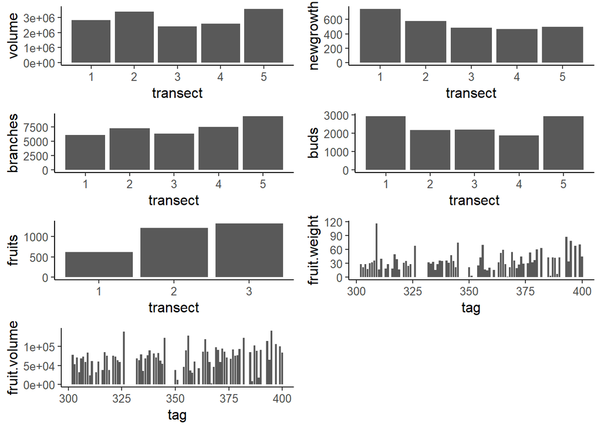

## Distributions of and relationships between reproductive outputs

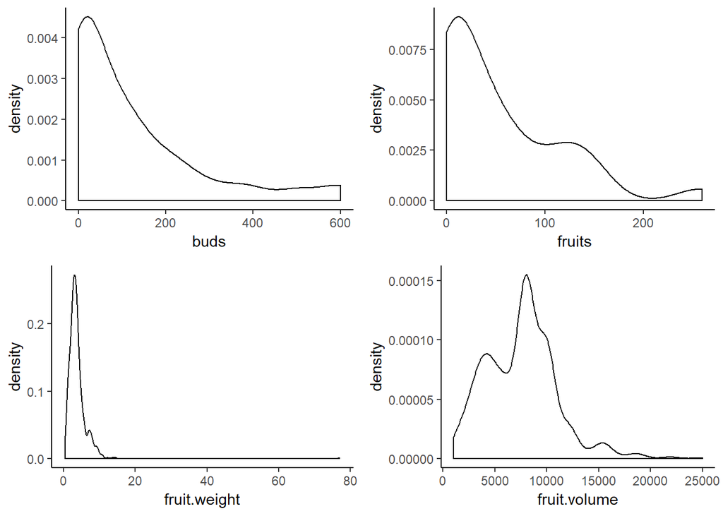

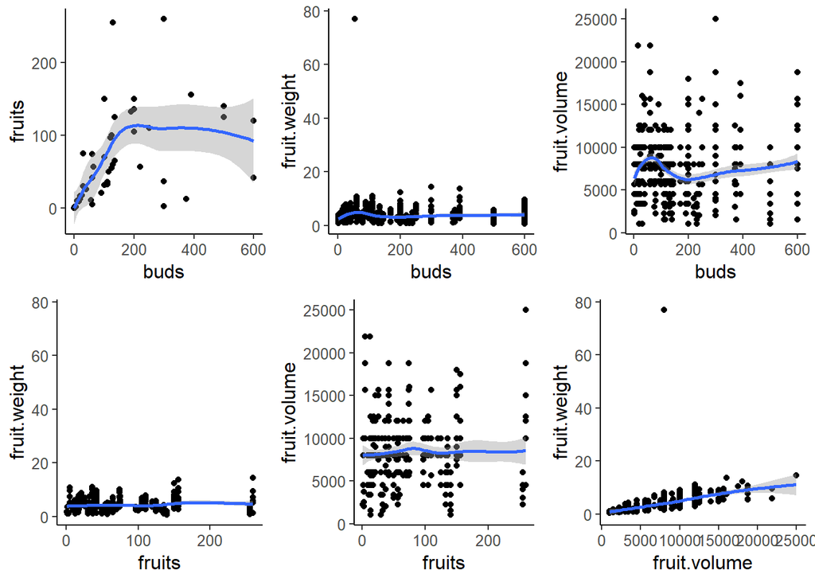

## Distributions of and relationships between physical outputs

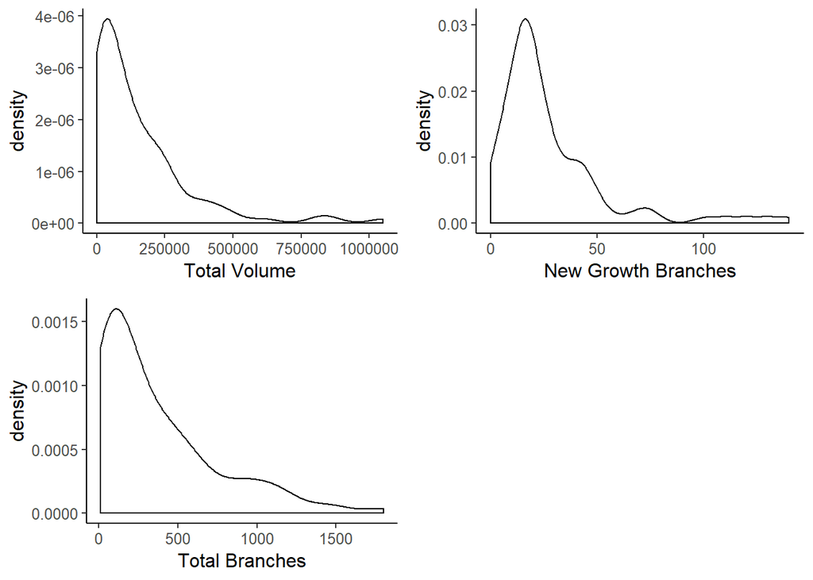

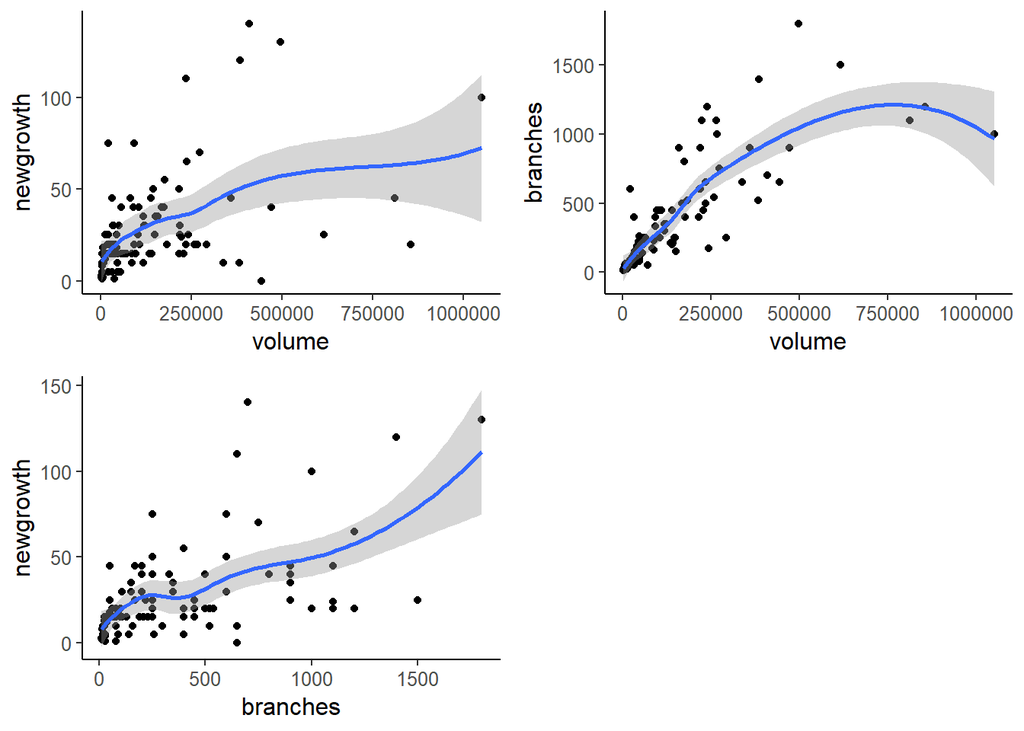

Here we examine different metrics for total size of a cactus against the reproductive output for each cactus (as represented by total number of floral buds).

## Size versus reproductive output: Buds

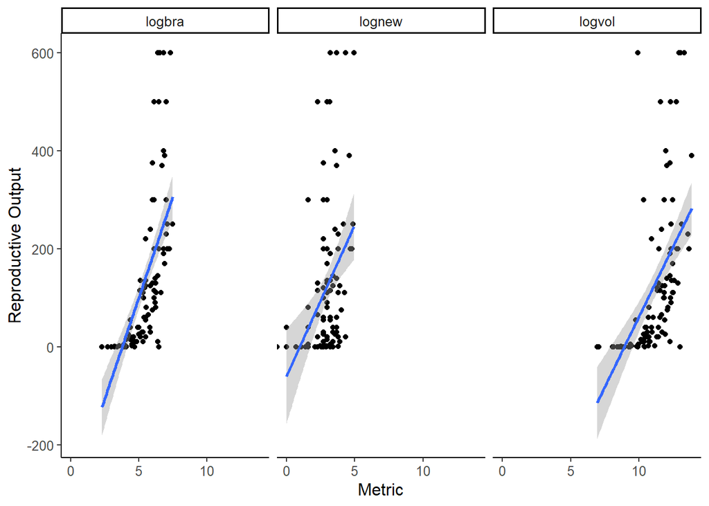

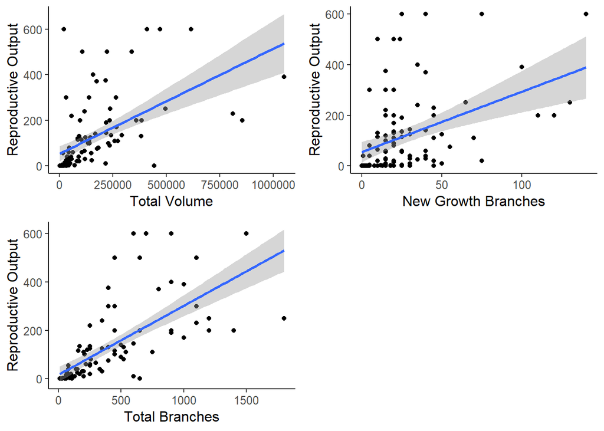

There is a large skew for smaller plants in our sampling resulting in a Poisson Distribution, which makes it difficult to know if there is actually a trade off in allocation happening.

## Size versus reproduction: Fruits

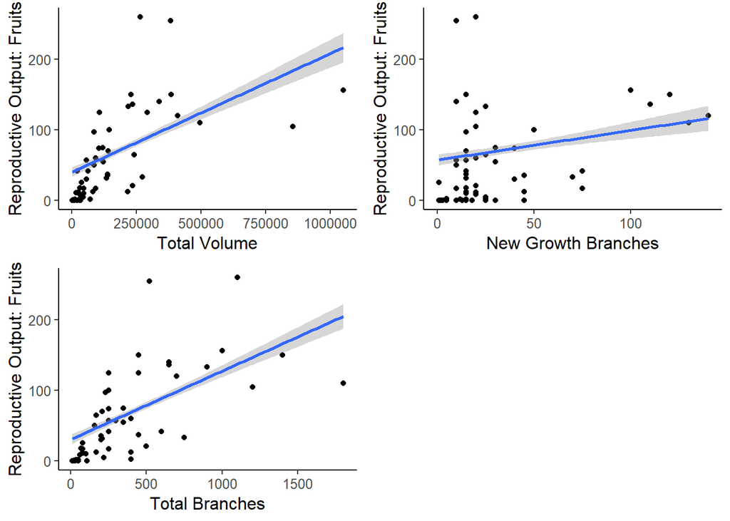

## Size versus reproduction: Fruit weight

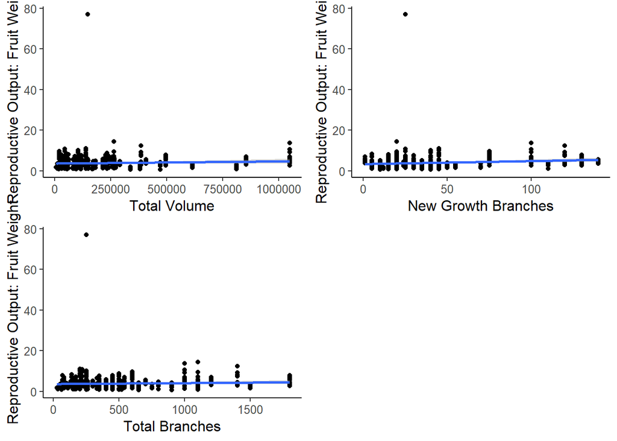

## Size versus reproduction: Fruit volume

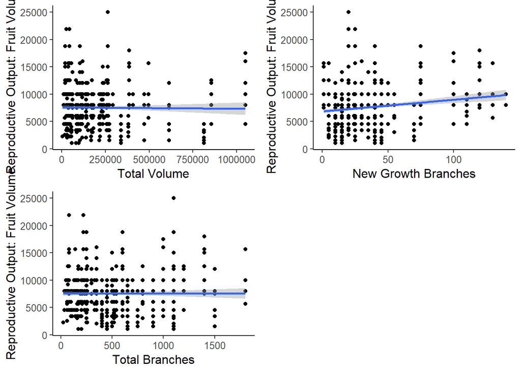

## Per Capita Size as Predictor Variables

Because it stands that larger plants have more branches, and therefore, more apical nodes from which buds can grow, we should investigate buds-per-branch as a standardized metric for reproductive output.

```
##   cactus.id tag  X      lat       lon   x   y  z  volume newgrowth health
## 1         1 400 NA 34.78159 -115.6625  53  49 52  135044        15      5
## 2         2 399 NA 34.78162 -115.6625  71  60 55  234300        20      3
## 3         3 398 NA 34.78164 -115.6624  20  13 23    5980        18      5
## 4         4 397 NA 34.78157 -115.6624 120 103 85 1050600       100      4
## 5         5 396 NA 34.78162 -115.6623   9   5 26    1170         3      5
## 6         6 395 NA 34.78164 -115.6622  82  63  4   20664        75      4
##   branches transect meter distance blooms buds fruits nest notes    logvol
## 1      210        1     5        1      1  100     32    1       11.813356
## 2      500        1    10        0      1   90     21    0       12.364358
## 3       50        1    15        2      0    0      0    0        8.696176
## 4     1000        1    20        4      1  390    156    1       13.864872
## 5       10        1    25        0      0    0      0    0        7.064759
## 6      600        1    30        0      1  600     42    0        9.936148
##     logbra   lognew budsperbranch
## 1 5.347108 2.708050     0.4761905
## 2 6.214608 2.995732     0.1800000
## 3 3.912023 2.890372     0.0000000
## 4 6.907755 4.605170     0.3900000
## 5 2.302585 1.098612     0.0000000
## 6 6.396930 4.317488     1.0000000
```

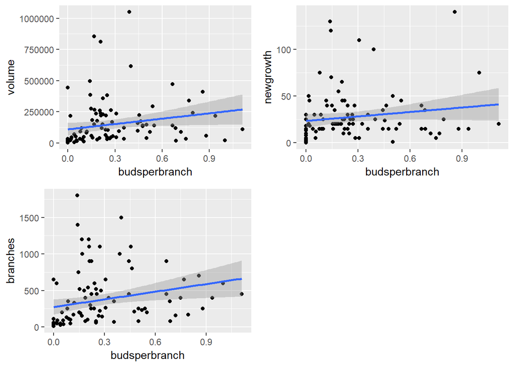

Even with accounting for buds/branch, the scatter plots of any size metric and buds as a reproductive output are funnel shaped. All this means is that future statistical models need to be built for a Poisson distribution.

# Models

## Test for multicolinearity and correlation between physical structure factors

```r
#Correlation between sizes
#volume and new growth
vncor <- cor.test(paired$volume, paired$newgrowth, method="pearson")
vncor #positively correlated
```

```
##
##  Pearson's product-moment correlation
##
## data:  paired$volume and paired$newgrowth
## t = 5.1735, df = 98, p-value = 1.22e-06
## alternative hypothesis: true correlation is not equal to 0
## 95 percent confidence interval:
##  0.2934492 0.6045865
## sample estimates:
##       cor
## 0.4631707
```

```r
#volume and branches
vbcor <- cor.test(paired$volume, paired$branches, method="pearson")
vbcor # positively correlated
```

```
##
##  Pearson's product-moment correlation
##
## data:  paired$volume and paired$branches
## t = 12.515, df = 98, p-value < 2.2e-16
## alternative hypothesis: true correlation is not equal to 0
## 95 percent confidence interval:
##  0.6949209 0.8497961
## sample estimates:
##       cor
## 0.7842876
```

```r
#new growth and branches
nbcor <- cor.test(paired$newgrowth, paired$branches, method="pearson")
nbcor #positively correlated
```

```
##
##  Pearson's product-moment correlation
##
## data:  paired$newgrowth and paired$branches
## t = 6.7144, df = 98, p-value = 1.239e-09
## alternative hypothesis: true correlation is not equal to 0
## 95 percent confidence interval:
##  0.4101262 0.6824958
## sample estimates:
##      cor
## 0.561326
```

```r
#All predictors are correlated, so I believe we don't want interacting models.


#Correlation between reproductive output responses?
#buds and fruits
bfcor <- cor.test(paired$buds, paired$fruits, method="pearson")
bfcor #positively correlated
```

```
##
##  Pearson's product-moment correlation
##
## data:  paired$buds and paired$fruits
## t = 4.8485, df = 58, p-value = 9.697e-06
## alternative hypothesis: true correlation is not equal to 0
## 95 percent confidence interval:
##  0.3278193 0.6960464
## sample estimates:
##     cor
## 0.53704
```

```r
#blooms and fruits
bbcor <- cor.test(paired$blooms, paired$fruits, method="pearson")
bbcor #positively correlated
```

```
##
##  Pearson's product-moment correlation
##
## data:  paired$blooms and paired$fruits
## t = 3.3745, df = 58, p-value = 0.001324
## alternative hypothesis: true correlation is not equal to 0
## 95 percent confidence interval:
##  0.1685158 0.5975616
## sample estimates:
##       cor
## 0.4051059
```

```r
#buds and fruit weight
bfw <- cor.test(master$buds, master$fruit.weight, method="pearson")
bfw #not correlated
```

```
##
##  Pearson's product-moment correlation
##
## data:  master$buds and master$fruit.weight
## t = -0.049008, df = 688, p-value = 0.9609
## alternative hypothesis: true correlation is not equal to 0
## 95 percent confidence interval:
##  -0.07649596  0.07277997
## sample estimates:
##          cor
## -0.001868407
```

```r
#buds and fruit volume
bfv <- cor.test(master$buds, master$fruit.volume, method="pearson")
bfv #not correlated
```

```
##
##  Pearson's product-moment correlation
##
## data:  master$buds and master$fruit.volume
## t = -0.17508, df = 688, p-value = 0.8611
## alternative hypothesis: true correlation is not equal to 0
## 95 percent confidence interval:
##  -0.08127238  0.06799746
## sample estimates:
##          cor
## -0.006674644
```

```r
#fruit number and fruit weight
ffw <- cor.test(master$fruits, master$fruit.weight, method="pearson")
ffw #not correlated
```

```
##
##  Pearson's product-moment correlation
##
## data:  master$fruits and master$fruit.weight
## t = 1.4461, df = 415, p-value = 0.1489
## alternative hypothesis: true correlation is not equal to 0
## 95 percent confidence interval:
##  -0.02539481  0.16571136
## sample estimates:
##      cor
## 0.070808
```

```r
#fruit number and fruit volume
ffv <- cor.test(master$fruits, master$fruit.volume, method="pearson")
ffv #not correlated
```

```
##
##  Pearson's product-moment correlation
##
## data:  master$fruits and master$fruit.volume
## t = 0.35697, df = 415, p-value = 0.7213
## alternative hypothesis: true correlation is not equal to 0
## 95 percent confidence interval:
##  -0.07864194  0.11335993
## sample estimates:
##        cor
## 0.01752052
```

```r
#fruit weight and fruit volume
fwfv <- cor.test(master$fruit.weight, master$fruit.volume, method="pearson")
fwfv #positively correlated
```

```
##
##  Pearson's product-moment correlation
##
## data:  master$fruit.weight and master$fruit.volume
## t = 13.93, df = 688, p-value < 2.2e-16
## alternative hypothesis: true correlation is not equal to 0
## 95 percent confidence interval:
##  0.4087134 0.5252917
## sample estimates:
##       cor
## 0.4690431
```

```r
#Correlation between

#Variance Inflation Factors
#We can tell when a factor is a problem in a model when it's VIF is much higher than the rest of the VIFs

#buds and size additive
vif(glm(buds~newgrowth + volume + branches, data=paired, family="quasipoisson"))
```

```
## newgrowth    volume  branches
##  1.663056  2.110843  2.895856
```

```r
#ok

#buds and size interactions
vif(glm(buds~newgrowth * volume * branches, data=paired, family="quasipoisson"))
```

```
##                 newgrowth                    volume
##                 28.939677                 26.355608
##                  branches          newgrowth:volume
##                  8.935625                 92.673389
##        newgrowth:branches           volume:branches
##                 68.037553                 33.937054
## newgrowth:volume:branches
##                137.532057
```

```r
#not ok

#fruit weight and size additive
vif(glm(fruit.weight ~ newgrowth + volume + branches, data=master, family="quasipoisson"))
```

```
## newgrowth    volume  branches
##  1.403936  2.229466  2.523663
```

```r
#ok

#fruit weight and size interactions
vif(glm(fruit.weight ~ newgrowth * volume * branches, data=master, family="quasipoisson"))
```

```
##                 newgrowth                    volume
##                  20.09368                  24.99163
##                  branches          newgrowth:volume
##                  12.67441                  71.82535
##        newgrowth:branches           volume:branches
##                  81.06888                  35.52867
## newgrowth:volume:branches
##                 141.65505
```

```r
#not ok

#fruit volume and size additive
vif(glm(fruit.volume~newgrowth + volume + branches, data=master, family="quasipoisson"))
```

```
## newgrowth    volume  branches
##  1.397784  2.250593  2.548703
```

```r
#ok

#fruit volume and size interactions
vif(glm(fruit.volume~newgrowth * volume * branches, data=master, family="quasipoisson"))
```

```
##                 newgrowth                    volume
##                  19.16325                  23.47662
##                  branches          newgrowth:volume
##                  12.13289                  62.10096
##        newgrowth:branches           volume:branches
##                  72.91152                  32.31146
## newgrowth:volume:branches
##                 120.22821
```

```r
#not ok

#fruits and fruit weight/volume additive
vif(glm(fruits~fruit.weight + fruit.volume, data=master, family="quasipoisson"))
```

```
## fruit.weight fruit.volume
##     2.631104     2.631104
```

```r
#ok

#fruits and fruit weight/volume interactions
vif(glm(fruits~fruit.weight * fruit.volume, data=master, family="quasipoisson"))
```

```
##              fruit.weight              fruit.volume
##                  6.768517                  4.433034
## fruit.weight:fruit.volume
##                 10.393665
```

```r
#maybe ok...maybe not ok.

#buds and fruit additive
vif(glm(buds~fruits + fruit.weight + fruit.volume, data=master, family="quasipoisson"))
```

```
##       fruits fruit.weight fruit.volume
##     1.015371     2.773783     2.752179
```

```r
#ok

#buds and fruit interactions
vif(glm(buds~fruits * fruit.weight * fruit.volume, data=master, family="quasipoisson"))
```

```
##                           fruits                     fruit.weight
##                         9.566462                        20.723698
##                     fruit.volume              fruits:fruit.weight
##                        14.240577                        34.263297
##              fruits:fruit.volume        fruit.weight:fruit.volume
##                        28.191347                        36.428910
## fruits:fruit.weight:fruit.volume
##                        37.991465
```

```r
#not ok

#generally, the interactive models have too many high and low VIFS
```

## Allocation between physical and reproductive structures: Buds

```r
#Volume as a predictor for repro output
m1 <- glm(buds~volume, data=paired, family="quasipoisson")
summary(m1) #significant
```

```
##
## Call:
## glm(formula = buds ~ volume, family = "quasipoisson", data = paired)
##
## Deviance Residuals:
##    Min      1Q  Median      3Q     Max
## -20.25  -12.31   -5.36    2.13   36.89
##
## Coefficients:
##              Estimate Std. Error t value Pr(>|t|)
## (Intercept) 4.353e+00  1.580e-01  27.558  < 2e-16 ***
## volume      2.188e-06  3.808e-07   5.747 1.03e-07 ***
## ---
## Signif. codes:  0 '***' 0.001 '**' 0.01 '*' 0.05 '.' 0.1 ' ' 1
##
## (Dispersion parameter for quasipoisson family taken to be 165.6444)
##
##     Null deviance: 17720  on 99  degrees of freedom
## Residual deviance: 13664  on 98  degrees of freedom
## AIC: NA
##
## Number of Fisher Scoring iterations: 6
```

```r
#New growth as predictor for repro output
m2 <- glm(buds~newgrowth, data=paired, family="quasipoisson")
summary(m2) #significant
```

```
##
## Call:
## glm(formula = buds ~ newgrowth, family = "quasipoisson", data = paired)
##
## Deviance Residuals:
##     Min       1Q   Median       3Q      Max
## -16.723  -12.704   -6.745    2.874   32.796
##
## Coefficients:
##             Estimate Std. Error t value Pr(>|t|)
## (Intercept) 4.355210   0.180849  24.082  < 2e-16 ***
## newgrowth   0.013003   0.003166   4.108  8.3e-05 ***
## ---
## Signif. codes:  0 '***' 0.001 '**' 0.01 '*' 0.05 '.' 0.1 ' ' 1
##
## (Dispersion parameter for quasipoisson family taken to be 184.7798)
##
##     Null deviance: 17720  on 99  degrees of freedom
## Residual deviance: 15242  on 98  degrees of freedom
## AIC: NA
##
## Number of Fisher Scoring iterations: 6
```

```r
#Number of branches as predictor for repro output
m3 <- glm(buds~branches, data=paired, family="quasipoisson")
summary(m3) #significant
```

```
##
## Call:
## glm(formula = buds ~ branches, family = "quasipoisson", data = paired)
##
## Deviance Residuals:
##     Min       1Q   Median       3Q      Max
## -25.770  -10.133   -4.700    2.791   29.027
##
## Coefficients:
##              Estimate Std. Error t value Pr(>|t|)
## (Intercept) 3.9830941  0.1635601  24.352  < 2e-16 ***
## branches    0.0015682  0.0001837   8.537 1.79e-13 ***
## ---
## Signif. codes:  0 '***' 0.001 '**' 0.01 '*' 0.05 '.' 0.1 ' ' 1
##
## (Dispersion parameter for quasipoisson family taken to be 118.8157)
##
##     Null deviance: 17720  on 99  degrees of freedom
## Residual deviance: 10494  on 98  degrees of freedom
## AIC: NA
##
## Number of Fisher Scoring iterations: 6
```

```r
#All are significant, so let's include all in one model
m4 <- glm(buds~newgrowth + volume + branches, data=paired, family="quasipoisson")
summary(m4) #significant
```

```
##
## Call:
## glm(formula = buds ~ newgrowth + volume + branches, family = "quasipoisson",
##     data = paired)
##
## Deviance Residuals:
##     Min       1Q   Median       3Q      Max
## -24.292  -10.204   -4.878    2.683   30.258
##
## Coefficients:
##               Estimate Std. Error t value Pr(>|t|)
## (Intercept)  3.978e+00  1.714e-01  23.208  < 2e-16 ***
## newgrowth   -4.356e-04  3.368e-03  -0.129    0.897
## volume       2.839e-07  5.699e-07   0.498    0.620
## branches     1.491e-03  3.200e-04   4.661 1.02e-05 ***
## ---
## Signif. codes:  0 '***' 0.001 '**' 0.01 '*' 0.05 '.' 0.1 ' ' 1
##
## (Dispersion parameter for quasipoisson family taken to be 122.571)
##
##     Null deviance: 17720  on 99  degrees of freedom
## Residual deviance: 10461  on 96  degrees of freedom
## AIC: NA
##
## Number of Fisher Scoring iterations: 6
```

```r
#posthoc of model that includes all factors
anova(m4, test="Chisq") #all factors important.
```

```
## Analysis of Deviance Table
##
## Model: quasipoisson, link: log
##
## Response: buds
##
## Terms added sequentially (first to last)
##
##
##           Df Deviance Resid. Df Resid. Dev  Pr(>Chi)
## NULL                         99      17720
## newgrowth  1   2477.9        98      15242 6.917e-06 ***
## volume     1   2099.8        97      13142 3.488e-05 ***
## branches   1   2681.0        96      10461 2.913e-06 ***
## ---
## Signif. codes:  0 '***' 0.001 '**' 0.01 '*' 0.05 '.' 0.1 ' ' 1
```

```r
m5 <- glm(buds~newgrowth * volume * branches, data=paired, family="quasipoisson")
summary(m5) #branches and volume:branches are significant, but this is an inappropriate model due to high VIFS
```

```
##
## Call:
## glm(formula = buds ~ newgrowth * volume * branches, family = "quasipoisson",
##     data = paired)
##
## Deviance Residuals:
##     Min       1Q   Median       3Q      Max
## -20.346   -6.689   -4.187    2.459   26.529
##
## Coefficients:
##                             Estimate Std. Error t value Pr(>|t|)
## (Intercept)                2.803e+00  3.878e-01   7.230 1.39e-10 ***
## newgrowth                  1.869e-02  1.314e-02   1.422  0.15833
## volume                     3.380e-06  1.854e-06   1.823  0.07151 .
## branches                   3.697e-03  6.132e-04   6.029 3.39e-08 ***
## newgrowth:volume          -5.512e-09  3.607e-08  -0.153  0.87886
## newgrowth:branches        -2.730e-05  1.633e-05  -1.671  0.09809 .
## volume:branches           -4.762e-09  1.683e-09  -2.829  0.00573 **
## newgrowth:volume:branches  2.344e-11  3.868e-11   0.606  0.54592
## ---
## Signif. codes:  0 '***' 0.001 '**' 0.01 '*' 0.05 '.' 0.1 ' ' 1
##
## (Dispersion parameter for quasipoisson family taken to be 87.05599)
##
##     Null deviance: 17720.1  on 99  degrees of freedom
## Residual deviance:  7188.2  on 92  degrees of freedom
## AIC: NA
##
## Number of Fisher Scoring iterations: 6
```

```r
#posthoc of model with all factors interactors
anova(m5, test="Chisq")
```

```
## Analysis of Deviance Table
##
## Model: quasipoisson, link: log
##
## Response: buds
##
## Terms added sequentially (first to last)
##
##
##                           Df Deviance Resid. Df Resid. Dev  Pr(>Chi)
## NULL                                         99    17720.1
## newgrowth                  1  2477.91        98    15242.2 9.548e-08 ***
## volume                     1  2099.83        97    13142.3 9.049e-07 ***
## branches                   1  2680.96        96    10461.4 2.867e-08 ***
## newgrowth:volume           1   251.14        95    10210.2  0.089416 .
## newgrowth:branches         1  2051.27        94     8159.0 1.209e-06 ***
## volume:branches            1   939.01        93     7220.0  0.001023 **
## newgrowth:volume:branches  1    31.80        92     7188.2  0.545577
## ---
## Signif. codes:  0 '***' 0.001 '**' 0.01 '*' 0.05 '.' 0.1 ' ' 1
```

```r
#Let's have volume (and then again number of branches) be considered as random factors, and try some GLMMs.

m6 <- glmer(buds~newgrowth + (1|volume) + (1|branches), data=paired, family="poisson")
summary(m6)
```

```
## Generalized linear mixed model fit by maximum likelihood (Laplace
##   Approximation) [glmerMod]
##  Family: poisson  ( log )
## Formula: buds ~ newgrowth + (1 | volume) + (1 | branches)
##    Data: paired
##
##      AIC      BIC   logLik deviance df.resid
##   1049.0   1059.4   -520.5   1041.0       96
##
## Scaled residuals:
##      Min       1Q   Median       3Q      Max
## -1.48191 -0.25459  0.00630  0.02868  0.39792
##
## Random effects:
##  Groups   Name        Variance Std.Dev.
##  volume   (Intercept) 1.190    1.091
##  branches (Intercept) 4.116    2.029
## Number of obs: 100, groups:  volume, 100; branches, 45
##
## Fixed effects:
##             Estimate Std. Error z value Pr(>|z|)
## (Intercept) 2.902938   0.397441   7.304 2.79e-13 ***
## newgrowth   0.016246   0.006953   2.336   0.0195 *
## ---
## Signif. codes:  0 '***' 0.001 '**' 0.01 '*' 0.05 '.' 0.1 ' ' 1
##
## Correlation of Fixed Effects:
##           (Intr)
## newgrowth -0.547
```

```r
#posthoc of model with volume and branches as random factors
anova(m6, test="Chisq") #significant, but maybe not really a good model, biologically speaking.
```

```
## Analysis of Variance Table
##           Df Sum Sq Mean Sq F value
## newgrowth  1 6.1632  6.1632  6.1632
```